# ¿Qué tan contentos se van los turistas de los Pueblos Mágicos?

Reporte · Rest-Mex 2025

Autor/a

## En una línea

De 207,838 reseñas de 40 Pueblos Mágicos, **87.3% vienen de turistas satisfechos** (4 o 5 de 5). Las quejas se concentran en hoteles y son más largas. Un modelo simple de palabras clave las distingue (AUC 0.84), pero **solo detecta 23.7% de las quejas** con el umbral por defecto.

## Los datos

Reseñas de TripAdvisor (2002–2024) del corpus Rest-Mex 2025 (conjunto de entrenamiento; Álvarez-Carmona et al., 2025), con la calificación que puso el propio turista: 1 = muy malo a 5 = muy bueno.

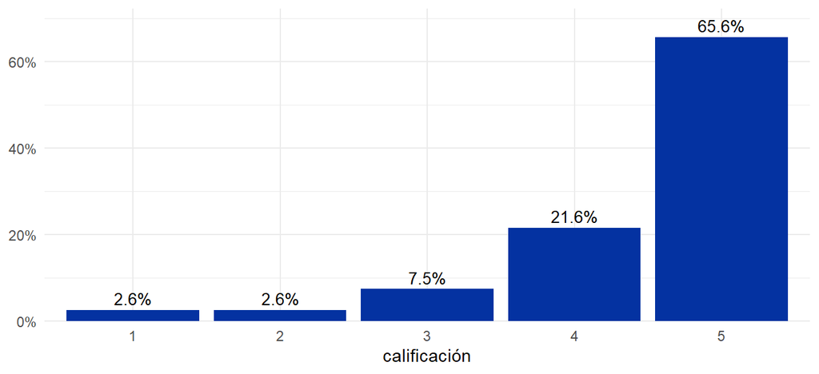

## Hallazgo 1 · Los hoteles reciben más quejas

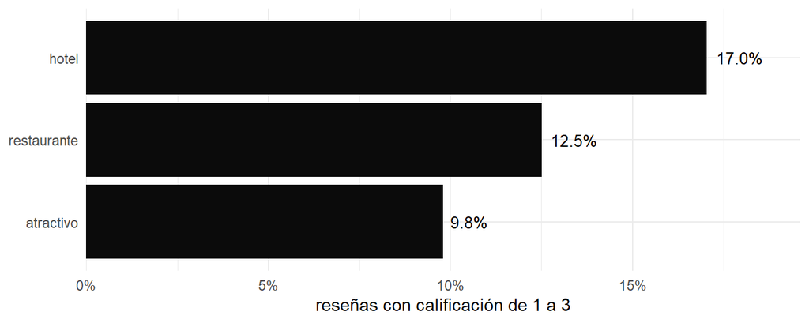

## Hallazgo 2 · Quien se queja escribe más

| satisfecho | mediana de palabras | reseñas |
| --- | --- | --- |
| no | 51 | 26428 |
| si | 45 | 181410 |

## El modelo

Una regresión logística entrenada con 32,000 reseñas y evaluada en otras 8,000 que nunca vio. Usa el tipo de lugar, la longitud y si aparecen 60 palabras escogidas en el entrenamiento.

| medida | valor |
| --- | --- |
| Exactitud (accuracy) | 88.6% |
| Exactitud de decir siempre «satisfecho» | 87.2% |
| Kappa de Cohen | 0.30 |
| AUC | 0.84 |
| Quejas detectadas (sensibilidad) | 23.7% |

**Ojo con la exactitud.** Un modelo que no lee nada y siempre dice «satisfecho» ya acierta el 87.2%. Por eso se reporta también la kappa, que descuenta ese acierto gratis, y cuántas quejas encuentra de verdad.

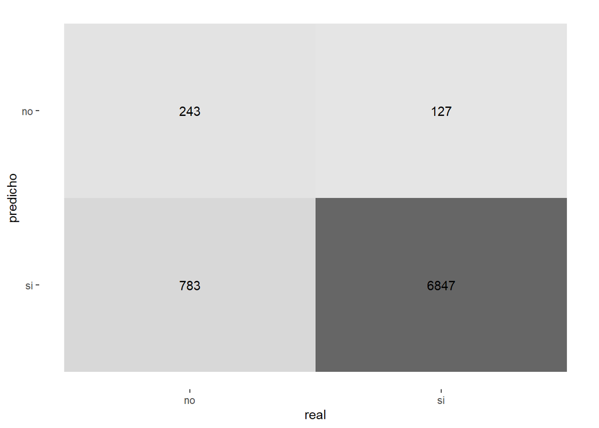

### Las palabras que más pesan

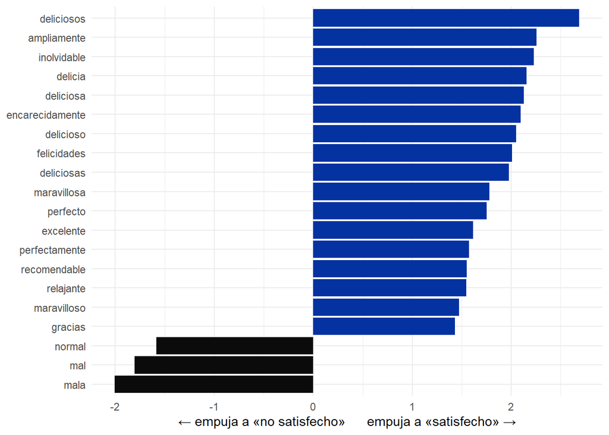

## Limitaciones

- Cortar en 4 es una decisión: el 3 («neutral») cuenta como no satisfecho.
- Las reseñas de TripAdvisor no son una muestra de todos los turistas: escribe quien quiere escribir.
- El modelo solo ve 60 palabras, una por una, sin orden. «No estuvo mal» le parece una queja.

## Siguiente paso

Bajar el umbral de decisión para detectar más quejas a cambio de más falsas alarmas, y probar con todas las palabras (`textrecipes`) en vez de 60.

## Fuente

Álvarez-Carmona, M. Á. et al. (2025). Overview of Rest-Mex at IberLEF 2025: Researching Sentiment Evaluation in Text for Mexican Magical Towns. *Procesamiento del Lenguaje Natural*, 75, 499–511. Datos de uso exclusivamente académico y de investigación.